# Analyze A/B Test Results

- Introduction
- Part I - Probability
- Part II - A/B Test
- Part III - Logistic Regression

## Introduction

An e-commerce company is considering **introducing a new version of a webpage.**  
The company is interested in running an A/B test to determine if the implementation of the webpage's new format will create more sales transactions than the old webpage.

| user_id | timestamp | group | landing_page | converted |
| --- | --- | --- | --- | --- |
| XXXX | XXXX | `control` | `old_page` | X |
| XXXX | XXXX | `treatment` | `new_page` | X |

## Part I - Probability

The libraries that are imported:

`pandas` (data manipulation and analysis)  
`numpy` (mathematical operations on arrays)  
`matplotlib` (library to plot graphs)

`statsmodels` (statistical data exploration)  
`Image` (display images)

```python
import pandas as pd
import numpy as np
import random
import statsmodels.api as sm
import matplotlib.pyplot as plt
%matplotlib inline
random.seed(42)
from IPython.display import Image
```

### Data Wrangling: Gather - Assess - Clean

#### Gather

The dataset:

```python
df = pd.read_csv('ab_data.csv')
df.sample(5)
```

|  | user_id | timestamp | group | landing_page | converted |
| --- | --- | --- | --- | --- | --- |
| 204777 | 880686 | 2017-01-08 02:38:40.981881 | treatment | new_page | 0 |
| 79324 | 737601 | 2017-01-22 16:36:20.311486 | treatment | new_page | 0 |
| 157071 | 683354 | 2017-01-14 12:52:37.313367 | control | old_page | 0 |
| 245530 | 713459 | 2017-01-22 13:07:55.762608 | control | old_page | 0 |
| 171932 | 727698 | 2017-01-04 23:12:30.221259 | treatment | old_page | 0 |

#### Assess

```python
df.shape
```

```
(294478, 5)
```

The dataset contains `294,478 rows` and 5 `columns`:  
`user_id` : Unique ID  
`timestap`: Time stamp when the user visited the webpage.  
`group`: **control** group is served the old website, **treatment** group is served the new website.  
`landing_page`: It denotes whether the user visited the **old** or **new** webpage.  
`converted`: It denotes whether the user decided to pay for the company's product. `1` means the user bought the product.

```python
df.info()
# all columns have 294,478 items, matching the 294,478 rows. Thus no missing values
```

```
<class 'pandas.core.frame.DataFrame'>
RangeIndex: 294478 entries, 0 to 294477
Data columns (total 5 columns):
 #   Column        Non-Null Count   Dtype
---  ------        --------------   -----
 0   user_id       294478 non-null  int64
 1   timestamp     294478 non-null  object
 2   group         294478 non-null  object
 3   landing_page  294478 non-null  object
 4   converted     294478 non-null  int64
dtypes: int64(2), object(3)
memory usage: 11.2+ MB
```

22 days is the A/B test time period:

```python
timeframe = pd.Timestamp(df['timestamp'].max()).round(freq='d')- pd.Timestamp(df['timestamp'].min()).round(freq='d')
timeframe
```

```
Timedelta('22 days 00:00:00')
```

The proportion of users, regardless of the page's version,that made a purchase is :

```python
df.converted.mean()
```

```
0.11965919355605512
```

```python
df.query('group =="treatment" & landing_page != "new_page"').group.count()
```

```
1965
```

```python
df.query('group =="control" & landing_page != "old_page"').group.count()
```

```
1928
```

> Issue `1`: inaccurate rows are present in the dataset.  
> The `control` group should be only viewing the `old_page`.  
> Likewise, the `treatment` group should be only viewing the `new_page`.  
> However, 1,965 `treatment` users are matched with the `old_page`, while 1,928 `control` users are matched with the `new_page`.

```python
df.nunique()
```

```
user_id         290584
timestamp       294478
group                2
landing_page         2
converted            2
dtype: int64
```

```python
df.shape[0] - df.user_id.nunique()
```

```
3894
```

> Issue `2`: Each row should have a unique `user_id`  
> But there are 3,894 rows with duplicate `user_id`.

```python
df.isna().sum()
```

```
user_id         0
timestamp       0
group           0
landing_page    0
converted       0
dtype: int64
```

#### Clean

- **Fix issue `1`: Remove the inaccurate rows, and store the result in a new dataframe.**

```python
df_=df.query('(group == "control" & landing_page == "new_page") | (group=="treatment" & landing_page == "old_page")')

df_.shape[0]
```

```
3893
```

```python
df_v1 = df.drop(df_.index)
```

```python
df_v1.shape
```

```
(290585, 5)
```

A check to confirm all inaccurate rows were removed from the `df_v1` dataset:

```python
df_v1[((df_v1['group'] == 'treatment') == (df_v1['landing_page'] == 'new_page')) == False].shape[0]
```

```
0
```

- **Fix issue `2`: remove rows wih duplicate** `user_id`

```python
df_v1.shape[0]
```

```
290585
```

```python
df_v1.user_id.nunique()
```

```
290584
```

After fixing the first issue, there is now only one duplicate `user_id`.

```python
df_v1.groupby('user_id')['timestamp'].count().reset_index().sort_values(by=['timestamp'], ascending=False).head()
```

|  | user_id | timestamp |
| --- | --- | --- |
| 131712 | 773192 | 2 |
| 0 | 630000 | 1 |
| 193720 | 840701 | 1 |
| 193726 | 840707 | 1 |
| 193725 | 840706 | 1 |

```python
df_v1.query('user_id ==773192')
```

|  | user_id | timestamp | group | landing_page | converted |
| --- | --- | --- | --- | --- | --- |
| 1899 | 773192 | 2017-01-09 05:37:58.781806 | treatment | new_page | 0 |
| 2893 | 773192 | 2017-01-14 02:55:59.590927 | treatment | new_page | 0 |

```python
df_v1.drop([1899], inplace = True)
```

```python
df_v1.query('user_id ==773192')
```

|  | user_id | timestamp | group | landing_page | converted |
| --- | --- | --- | --- | --- | --- |
| 2893 | 773192 | 2017-01-14 02:55:59.590927 | treatment | new_page | 0 |

```python
df_v1.shape
```

```
(290584, 5)
```

The two issues that were identified with the original dataset:  
`1.` inaccurate rows with `control`-`new_page` & `treatment`-`old_page` pairs were removed and  
`2.` a duplicate instance of `user_id` has been removed as well.

A few questions to better understand the customers' behavior:

**α.** What is the probability of an individual converting regardless of the page they receive?

**β.** Given that an individual was in the `control` group, what is the probability they converted?

**γ.** Given that an individual was in the `treatment` group, what is the probability they converted?

**δ.** What is the actual difference (`obs_diff`) between the conversion rates for the two groups?

**ε.** What is the probability that an individual received the new page?

**ζ.** Considering the answers from parts (α) through (ε) above, does the new webpage lead to more conversions?

**α.** What is the probability of an individual converting regardless of the page they receive?

```python
df_v1.converted.mean()
```

```
0.11959708724499628
```

The probability for a random user to complete a transaction is approximately **11.96%**.

**β.** Given that an individual was in the `control` group, what is the probability they converted?

```python
control = df_v1.query("group=='control'").converted.mean()
control
```

```
0.1203863045004612
```

The probability a user viewed the old format page and completed a transaction is **12.04%**.

**γ.** Given that an individual was in the `treatment` group, what is the probability they converted?

```python
treatment = df_v1.query("group=='treatment'").converted.mean()
treatment
```

```
0.11880806551510564
```

The probability a user viewed the new format page and completed a transaction is **11.88%**.

**δ.** What is the actual difference (obs_diff) between the conversion rates for the two groups?

```python
obs_diff = treatment - control
obs_diff
```

```
-0.0015782389853555567
```

The actual difference between the two groups' conversion rates is **-0.16%**.

**ε.** What is the probability that an individual received the new page?

```python
df_v1.query('landing_page=="new_page"')['user_id'].count()/df_v1.shape[0]
```

```
0.5000619442226688
```

The probability a user viewed the new format page is approximately **50%**.

**ζ**. Among the 290,584 people , approximately half of them (50.006%) were treated the new page (`treatment` group), while the other half accessed the old page (`control` group).  
The %age of people that made a purchase after landing on the new page ( treatment group conversion rate) is **11.88%** and  
the %age of people making a purchase when using the old page ( control group conversion rate) is **12.03%**.

> Conclusion: **It appears there are slightly fewer sales (fewer conversions), when people are directed to the new page.**

## Part II - A/B Test

```python
df_clean = df_v1.copy()
```

**$p_{old}$:** The conversion rate (user accesses the *old* page).  
**$p_{new}$:** The conversion rate (user accesses the *new* page).

The alternative hypothesis **H<sub>1</sub>** is that the new page conversion rate is higher than the old page conversion rate.  
The null hypothesis **H<sub>0</sub>** is that the old page conversion rate is higher than or equal to the new page conversion rate .

### Null Hypothesis **$H_0$**: **$p_{new}$** - **$p_{old} \leq$** 0

### Alternative Hypothesis **$H_1$**: **$p_{new}$** - **$p_{old}$** > 0

#### Testing Null Hypothesis $H_0$

Under the null hypothesis $H_0$, assume that

- $p_{new}$ and $p_{old}$ are equal, and
- that $p_{new}$ and $p_{old}$ both are equal to the **converted** success rate in the `df_v1` data regardless of the page.  
  So, the assumption is:

  $p_{new}$ = $p_{old}$ = $p_{population}$

Next steps:

- Simulate (bootstrap) sample data set for both groups, and compute the "converted" probability $p$ for those samples.
- Use a sample size for each group equal to the ones in the `df_v1` data.
- Compute the difference in the "converted" probability for the two samples above.
- Perform the sampling distribution for the "difference in the converted probability" between the two simulated-samples over 10,000 iterations; and calculate an estimate.

**α.** The **conversion rate** for $p_{new}$ under the null hypothesis:

```python
p_new = df_clean.converted.mean()
p_new
```

```
0.11959708724499628
```

**β.** The **conversion rate** for $p_{old}$ under the null hypothesis:

```python
p_old = df_clean.converted.mean()
p_old
```

```
0.11959708724499628
```

**γ.** $n_{new}$, the number of individuals in the `treatment` group:

```python
n_new = len(df_clean.query('group == "treatment"'))
n_new
```

```
145310
```

**δ.** $n_{old}$, the number of individuals in the `control` group:

```python
n_old = len(df_clean.query('group != "treatment"'))
n_old
```

```
145274
```

**ε. Sample simulation for the `treatment` group**  
$n_{new}$ transactions will be simulated with a conversion rate of $p_{new}$ under the null hypothesis:

```python
# Simulate a sample for the treatment group
new_page_converted = np.random.choice([1,0], n_new,p=[p_new, 1-p_new])
```

**ζ. Sample simulation for the `control` group**  
$n_{old}$ transactions will be simulated with a conversion rate of $p_{old}$ under the null hypothesis:

```python
# Simulate a Sample for the control Group
old_page_converted = np.random.choice([1,0], n_old,p=[p_old, 1-p_old])
```

```python
new_page_converted.mean(), old_page_converted.mean()
```

```
(0.11873236528800496, 0.11925051970758704)
```

**η.** The difference in the "converted" probability $(p{'}_{new}$ - $p{'}_{old})$ for the simulated samples from the parts (ε) and (ζ):

```python
obs_diff_v2= new_page_converted.mean() - old_page_converted.mean()
obs_diff_v2
```

```
-0.0005181544195820842
```

**θ. Bootstraping**  
Re-create `new_page_converted` and `old_page_converted` and find the $(p{'}_{new}$ - $p{'}_{old})$ value 10,000 times using the same simulation process and store all $(p{'}_{new}$ - $p{'}_{old})$ values in `p_diffs`:

```python
# Sampling distribution
p_diffs = []
for s in range(10000):
    new_page_converted =  np.random.choice([0,1], n_new, p = [p_new, 1-p_new])
    old_page_converted =  np.random.choice([0,1], n_old, p = [p_old, 1-p_old])
    obs_diff_v3 = new_page_converted.mean() - old_page_converted.mean()
    p_diffs.append(obs_diff_v3)
```

**ι. Plot the distribution**

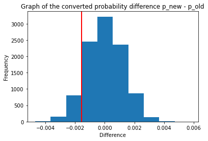

```python
plt.hist(p_diffs)
plt.title('Graph of the converted probability difference p_new - p_old')
plt.xlabel('Difference')
plt.ylabel('Frequency')
plt.axvline(x = obs_diff, color = 'red', linewidth = 2);
```

**κ.** What proportion of the `p_diffs` are greater than the actual difference observed in the `df_clean` data?

```python
(np.array(p_diffs)> obs_diff).mean()
```

```
0.9064
```

### Another way for comparing the mean of two independent and normal distribution samples is . . .

... a two-sample z-test and calculation of the Z_score:

$$ Z_{score} = \frac{ (p{'}_{new}-p{'}_{old}) - (p_{new} - p_{old})}{ \sqrt{ \frac{\sigma^{2}_{new} }{n_{new}} + \frac{\sigma^{2}_{old} }{n_{old}} } } $$

Next step is to make a decision to reject or fail to reject the null hypothesis based on comparing these two values:

- $Z_{score}$
- $Z_{\alpha}$ or $Z_{0.05}$, also known as critical value at 95% confidence interval. $Z_{0.05}$ is 1.645 for one-tailed tests, and 1.960 for two-tailed test.

```python
# number of conversions with the old_page
convert_old = df_clean.query('landing_page == "old_page" & converted==1').user_id.count()

# number of conversions with the new_page
convert_new = df_clean.query('landing_page != "old_page" & converted==1').user_id.count()

# number of individuals who were shown the old_page
no_convert_old = df_clean.query('landing_page == "old_page"').user_id.count()

# number of individuals who received the new_page
no_convert_new = df_clean.query('landing_page != "old_page"').user_id.count()

convert_old, convert_new, no_convert_old, no_convert_new
```

```
(17489, 17264, 145274, 145310)
```

```python
z_score, p_value = sm.stats.proportions_ztest([convert_new, convert_old], [n_new, n_old],alternative='larger')
z_score, p_value
```

```
(-1.3109241984234394, 0.9050583127590245)
```

$Z_{score}$ is calculated at -1.31 and the $Z_{a}$=$Z_{0.05}$ is 1.645.  
This is a right-tailed test, and because $Z_{score}$ < $Z_{a}$, **we fail to reject the null hypothesis**.  
The `p-value` is similar to the one we calculated at **κ.** , which says that we have ~90% probability of observing the difference, given that the null is true.  
Both the $Z_{score}$ and `p-value` confirm that **we fail to reject the null hypothesis**.

### Part III - Logistic Regression

In the last part of the project, **I will be conducting the A/B test by performing a Logistic Regression**.  
The response variable `converted` is binary, thus a logistic regression is the statistical technique to predict the relationship between predictor variables and the response variable.

A couple of points:

1. add `intercept`column - It should be `1` in the entire column. [(Why?)](https://stats.stackexchange.com/questions/440242/statsmodels-logistic-regression-adding-intercept)
2. add `ab_page` column - It's a dummy variable column, having a value `1` when an individual receives the `treatment`, otherwise `0`. [(Why?)](https://medium.com/@curryrowan/simplified-logistic-regression-classification-with-categorical-variables-in-python-1ce50c4b137)

```python
df_clean['intercept'] = 1
df_clean['ab_page'] = pd.get_dummies(df_clean['group'])['treatment']
```

```python
model = sm.Logit(df_clean['converted'], df_clean[['intercept', 'ab_page']])
results = model.fit()
results.summary2()
```

```
Optimization terminated successfully.
         Current function value: 0.366118
         Iterations 6
```

| Model: | Logit | Pseudo R-squared: | 0.000 |
| --- | --- | --- | --- |
| Dependent Variable: | converted | AIC: | 212780.3502 |
| Date: | 2022-06-01 14:47 | BIC: | 212801.5095 |
| No. Observations: | 290584 | Log-Likelihood: | -1.0639e+05 |
| Df Model: | 1 | LL-Null: | -1.0639e+05 |
| Df Residuals: | 290582 | LLR p-value: | 0.18988 |
| Converged: | 1.0000 | Scale: | 1.0000 |
| No. Iterations: | 6.0000 |  |  |

|  | Coef. | Std.Err. | z | P>\|z\| | [0.025 | 0.975] |
| --- | --- | --- | --- | --- | --- | --- |
| intercept | -1.9888 | 0.0081 | -246.6690 | 0.0000 | -2.0046 | -1.9730 |
| ab_page | -0.0150 | 0.0114 | -1.3109 | 0.1899 | -0.0374 | 0.0074 |

The `ab_page`'s **p-value** is 0.1899.  
Type I error is 0.05.  
Answer: The significance test results in a probability higher than the Type I error, thus the data provides little to no evidence that the null hypothesis is false.  
We fail to reject the null hypothesis.

#### Update: New data and recalculating the Logistic Regression

The e-commerce company decided to provide additional data: *the country that each user resides.*  
I will incorporate the new information (i.e. join the `df_clean` and `df_countries` dataframes) into one dataframe and run new logistic regression models.

```python
df_countries = pd.read_csv('countries.csv')
df_countries.head()
```

|  | user_id | country |
| --- | --- | --- |
| 0 | 834778 | UK |
| 1 | 928468 | US |
| 2 | 822059 | UK |
| 3 | 711597 | UK |
| 4 | 710616 | UK |

```python
# Join df_clean and df_countries dataframes
df__ = df_countries.set_index('user_id').join(df_clean.set_index('user_id'), how='inner')
df__.head()
```

| user_id | country | timestamp | group | landing_page | converted | intercept | ab_page |
| --- | --- | --- | --- | --- | --- | --- | --- |
| 834778 | UK | 2017-01-14 23:08:43.304998 | control | old_page | 0 | 1 | 0 |
| 928468 | US | 2017-01-23 14:44:16.387854 | treatment | new_page | 0 | 1 | 1 |
| 822059 | UK | 2017-01-16 14:04:14.719771 | treatment | new_page | 1 | 1 | 1 |
| 711597 | UK | 2017-01-22 03:14:24.763511 | control | old_page | 0 | 1 | 0 |
| 710616 | UK | 2017-01-16 13:14:44.000513 | treatment | new_page | 0 | 1 | 1 |

```python
# Create the necessary dummy variables
df_lg = pd.get_dummies(df__['country']).join(df__, how='inner')
df_lg.head()
```

| user_id | CA | UK | US | country | timestamp | group | landing_page | converted | intercept | ab_page |
| --- | --- | --- | --- | --- | --- | --- | --- | --- | --- | --- |
| 834778 | 0 | 1 | 0 | UK | 2017-01-14 23:08:43.304998 | control | old_page | 0 | 1 | 0 |
| 928468 | 0 | 0 | 1 | US | 2017-01-23 14:44:16.387854 | treatment | new_page | 0 | 1 | 1 |
| 822059 | 0 | 1 | 0 | UK | 2017-01-16 14:04:14.719771 | treatment | new_page | 1 | 1 | 1 |
| 711597 | 0 | 1 | 0 | UK | 2017-01-22 03:14:24.763511 | control | old_page | 0 | 1 | 0 |
| 710616 | 0 | 1 | 0 | UK | 2017-01-16 13:14:44.000513 | treatment | new_page | 0 | 1 | 1 |

```python
model_lg1 = sm.Logit(df_lg['converted'], df_lg[['intercept', 'UK', 'CA']])
result_1 = model_lg1.fit()
result_1.summary2()
```

```
Optimization terminated successfully.
         Current function value: 0.366116
         Iterations 6
```

| Model: | Logit | Pseudo R-squared: | 0.000 |
| --- | --- | --- | --- |
| Dependent Variable: | converted | AIC: | 212780.8333 |
| Date: | 2022-06-01 14:48 | BIC: | 212812.5723 |
| No. Observations: | 290584 | Log-Likelihood: | -1.0639e+05 |
| Df Model: | 2 | LL-Null: | -1.0639e+05 |
| Df Residuals: | 290581 | LLR p-value: | 0.19835 |
| Converged: | 1.0000 | Scale: | 1.0000 |
| No. Iterations: | 6.0000 |  |  |

|  | Coef. | Std.Err. | z | P>\|z\| | [0.025 | 0.975] |
| --- | --- | --- | --- | --- | --- | --- |
| intercept | -1.9967 | 0.0068 | -292.3145 | 0.0000 | -2.0101 | -1.9833 |
| UK | 0.0099 | 0.0133 | 0.7458 | 0.4558 | -0.0161 | 0.0360 |
| CA | -0.0408 | 0.0269 | -1.5178 | 0.1291 | -0.0935 | 0.0119 |

```python
model_lg2 = sm.Logit(df_lg['converted'], df_lg[['intercept', 'ab_page', 'UK', 'CA']])
result_2 = model_lg2.fit()
result_2.summary2()
```

```
Optimization terminated successfully.
         Current function value: 0.366113
         Iterations 6
```

| Model: | Logit | Pseudo R-squared: | 0.000 |
| --- | --- | --- | --- |
| Dependent Variable: | converted | AIC: | 212781.1253 |
| Date: | 2022-06-01 14:48 | BIC: | 212823.4439 |
| No. Observations: | 290584 | Log-Likelihood: | -1.0639e+05 |
| Df Model: | 3 | LL-Null: | -1.0639e+05 |
| Df Residuals: | 290580 | LLR p-value: | 0.17599 |
| Converged: | 1.0000 | Scale: | 1.0000 |
| No. Iterations: | 6.0000 |  |  |

|  | Coef. | Std.Err. | z | P>\|z\| | [0.025 | 0.975] |
| --- | --- | --- | --- | --- | --- | --- |
| intercept | -1.9893 | 0.0089 | -223.7628 | 0.0000 | -2.0067 | -1.9718 |
| ab_page | -0.0149 | 0.0114 | -1.3069 | 0.1912 | -0.0374 | 0.0075 |
| UK | 0.0099 | 0.0133 | 0.7433 | 0.4573 | -0.0162 | 0.0359 |
| CA | -0.0408 | 0.0269 | -1.5161 | 0.1295 | -0.0934 | 0.0119 |

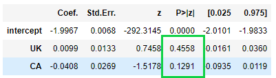

```python
Image("logistic_regression_1st_p-values.png")
```

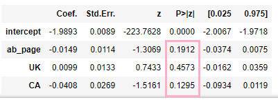

```python
Image("logistic_regression_2nd_p-values.png")
```

After running the two logistic regression models above, **we witness that p-values (highlighted above) on both models are higher than 0.05 ( Type I error), which indicates that the country parameter does not seem to play an important role to the conversion rate.**

> **Feature engineering**: Though I have looked at the individual factors of country and page on conversion, I will also look at an interaction between page and country to see if are there significant effects on conversion.

```python
df_lg['UK_abpage'] = df_lg['ab_page'] * df_lg['UK']
df_lg['CA_abpage'] = df_lg['ab_page'] * df_lg['CA']
df_lg.head()
```

| user_id | CA | UK | US | country | timestamp | group | landing_page | converted | intercept | ab_page | UK_abpage | CA_abpage |
| --- | --- | --- | --- | --- | --- | --- | --- | --- | --- | --- | --- | --- |
| 834778 | 0 | 1 | 0 | UK | 2017-01-14 23:08:43.304998 | control | old_page | 0 | 1 | 0 | 0 | 0 |
| 928468 | 0 | 0 | 1 | US | 2017-01-23 14:44:16.387854 | treatment | new_page | 0 | 1 | 1 | 0 | 0 |
| 822059 | 0 | 1 | 0 | UK | 2017-01-16 14:04:14.719771 | treatment | new_page | 1 | 1 | 1 | 1 | 0 |
| 711597 | 0 | 1 | 0 | UK | 2017-01-22 03:14:24.763511 | control | old_page | 0 | 1 | 0 | 0 | 0 |
| 710616 | 0 | 1 | 0 | UK | 2017-01-16 13:14:44.000513 | treatment | new_page | 0 | 1 | 1 | 1 | 0 |

```python
model_lg3 = sm.Logit(df_lg['converted'], df_lg[['intercept', 'UK', 'CA', 'UK_abpage', 'CA_abpage']])
result_3 = model_lg3.fit()
result_3.summary2()
```

```
Optimization terminated successfully.
         Current function value: 0.366113
         Iterations 6
```

| Model: | Logit | Pseudo R-squared: | 0.000 |
| --- | --- | --- | --- |
| Dependent Variable: | converted | AIC: | 212782.9259 |
| Date: | 2022-06-01 14:48 | BIC: | 212835.8241 |
| No. Observations: | 290584 | Log-Likelihood: | -1.0639e+05 |
| Df Model: | 4 | LL-Null: | -1.0639e+05 |
| Df Residuals: | 290579 | LLR p-value: | 0.27295 |
| Converged: | 1.0000 | Scale: | 1.0000 |
| No. Iterations: | 6.0000 |  |  |

|  | Coef. | Std.Err. | z | P>\|z\| | [0.025 | 0.975] |
| --- | --- | --- | --- | --- | --- | --- |
| intercept | -1.9967 | 0.0068 | -292.3145 | 0.0000 | -2.0101 | -1.9833 |
| UK | 0.0045 | 0.0175 | 0.2572 | 0.7970 | -0.0298 | 0.0389 |
| CA | -0.0073 | 0.0371 | -0.1963 | 0.8444 | -0.0799 | 0.0654 |
| UK_abpage | 0.0108 | 0.0228 | 0.4749 | 0.6349 | -0.0339 | 0.0555 |
| CA_abpage | -0.0674 | 0.0520 | -1.2967 | 0.1947 | -0.1694 | 0.0345 |

```python
model_lg4 = sm.Logit(df_lg['converted'], df_lg[['intercept','ab_page', 'UK', 'CA', 'UK_abpage', 'CA_abpage']])
result_4 = model_lg4.fit()
result_4.summary2()
```

```
Optimization terminated successfully.
         Current function value: 0.366109
         Iterations 6
```

| Model: | Logit | Pseudo R-squared: | 0.000 |
| --- | --- | --- | --- |
| Dependent Variable: | converted | AIC: | 212782.6602 |
| Date: | 2022-06-01 14:49 | BIC: | 212846.1381 |
| No. Observations: | 290584 | Log-Likelihood: | -1.0639e+05 |
| Df Model: | 5 | LL-Null: | -1.0639e+05 |
| Df Residuals: | 290578 | LLR p-value: | 0.19199 |
| Converged: | 1.0000 | Scale: | 1.0000 |
| No. Iterations: | 6.0000 |  |  |

|  | Coef. | Std.Err. | z | P>\|z\| | [0.025 | 0.975] |
| --- | --- | --- | --- | --- | --- | --- |
| intercept | -1.9865 | 0.0096 | -206.3440 | 0.0000 | -2.0053 | -1.9676 |
| ab_page | -0.0206 | 0.0137 | -1.5052 | 0.1323 | -0.0473 | 0.0062 |
| UK | -0.0057 | 0.0188 | -0.3057 | 0.7598 | -0.0426 | 0.0311 |
| CA | -0.0175 | 0.0377 | -0.4652 | 0.6418 | -0.0914 | 0.0563 |
| UK_abpage | 0.0314 | 0.0266 | 1.1807 | 0.2377 | -0.0207 | 0.0835 |
| CA_abpage | -0.0469 | 0.0538 | -0.8718 | 0.3833 | -0.1523 | 0.0585 |

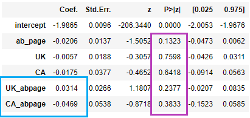

```python
Image("logistic_regression_coefficients_and_p-values.png")
```

```python
print(np.exp(0.0314)), print(np.exp(-0.0469));
```

```
1.0318981806179213
0.9541828111007262
```

Answer:  
**All p-values are above the Type I error rate α=0,05, thus we fail to reject the null hypothesis, they are statistically insignificant and we should not use the new page.**

**Intepreting the results from the last regression model above: holding all other variants constant, a UK user who gets the new page is 1.03 times more likely to convert, and a Canadian user who gets the new page is 0.95 times more likely to convert; both are practically and statistically insignificant.**